# Carbon Dynamics due to Sudden Oak Death and Fire Interactions in Big Sur

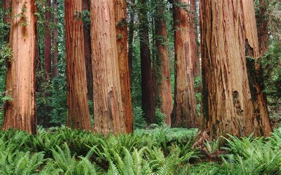

### Main research questions

1. How has carbon biomass changed due to fire and disease throughout the inventory? How has species (Tanoak, Coast Live Oak, Redwood, Bay Laurel) density and biomass been altered?
2. In diseased stands, when wildfire occurs do we see higher mortality in redwood than in non-diseased stands?
3. How does tanoak size interact with pathogen presence to determine mortality rates? Do we see that larger trees die when the pathogen is present?
   1. How does bay laurel density influence tanoak mortality rates?
4. How do state factors influence forest type and snag fall rates?
5. How does fire and disease influence coarse woody debris mass? How much CWD is burnt in fires? How does pathogen presence impact CWD pools?
6. Which factors, size, species, or burn status, influence CWD decomposition rates?

### Fire/disease graphical model

Through my research, I aim to quantify the fluxes between three main carbon pools – living biomass, snags and CWD. Below I outline the proposed carbon cycle between these main pools.

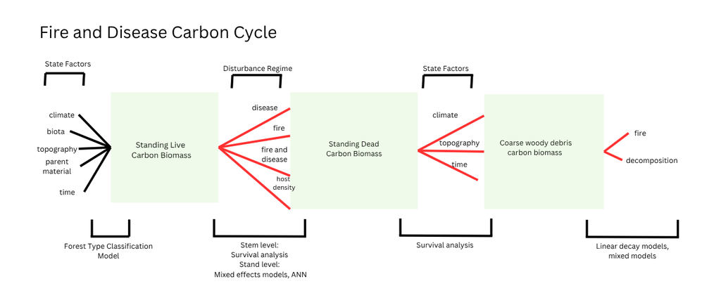

## Methods

#### Libraries Needed

```r
library(leaflet)
library(gt)
library(arrow)
library(stringr)
library(broom)
library(gtsummary)
library(survival)
library(ggsurvfit)
library(lme4)
library(lmerTest)
library(knitr)
library(kableExtra)
library(ggalluvial)
library(tidyverse)
library(bigsurrr)
library(patchwork)
library(furrr)
library(sf)
library(performance)
library(lavaan)
library(bestNormalize)
library(ggridges)
```

### Random Sampling Data Exploration

Below, I seek to understand the sampling bias throughout the inventory. I use monte carlo simulation to test “randomness” by simulating a random poisson distribution and compare z-scores between our dataset and the simulated dataset.

```r
bias <- read_parquet("./data/arrow/monte.parquet")
z_score <- function(df,x){
  df1 <- df |>
    summarize(
      pop_mean <- mean({{x}}, na.rm=TRUE),
      pop_sd <- sd({{x}}, na.rm=TRUE)) |>
        rename(Mean = 1, Sd = 2)
  df <- df |>
    mutate(ZScore = ({{x}} - df1$Mean)/ df1$Sd)
  return(df)
}
#sd = 2.311 mean=3.21
# plotted bias histogram to verify Poisson distribution
bias_mod1 <- z_score(bias, TotalTimesInventoried)

# simulate poisson distribution 280 total, mean of 3.2
set.seed(331)
sim <- data.frame(Simulated = rpois(280,3.2))
sim_mod1 <- z_score(sim,Simulated)

# simulated zscore dataset is slightly right skewed, project dataset is heavily right skewed
# simulated zscore dataset has no values over ~3 while project dataset has values near 4
# radius is built on times inventoried
# color will be built on z-score
# project dataset, if z-score < -0.5 they get green
# if z-score > 3 they get red
# use of binning 3
bias_mod2 <- bias_mod1 |>
  mutate(Color = case_when(
                           ZScore < -0.5 ~ "Green",
                           ZScore > 2.75 ~ "Red",
                           TRUE ~ "Blue"
                           ))

map <- bias_mod2

leaflet(map) %>%
  addTiles() %>%
  addProviderTiles(providers$Esri.WorldImagery) %>%
  setView(lng = mean(map$Lon), lat = mean(map$Lat), zoom = 9) %>%
  addCircleMarkers(
    lng = ~Lon,
    lat = ~Lat,
    radius = ~Radius * 1.2,  # scale up for visibility
    label = ~Plot,
    popup = ~paste0(
      "<b>Plot:</b> ", Plot, "<br>",
      "<b>Times Inventoried:</b> ", TotalTimesInventoried, "<br>",
      "<b>Visit Frequency:</b> ", VisitFrequency
    ),
    color = ~Color,
    fillOpacity = 0.7
  ) |>
  addControl(
    html = "<b style='font-size:12px;'>Bias in Sampling Frequency</b>",
    position = "topright"
  )
```

[interactive chart not shown]

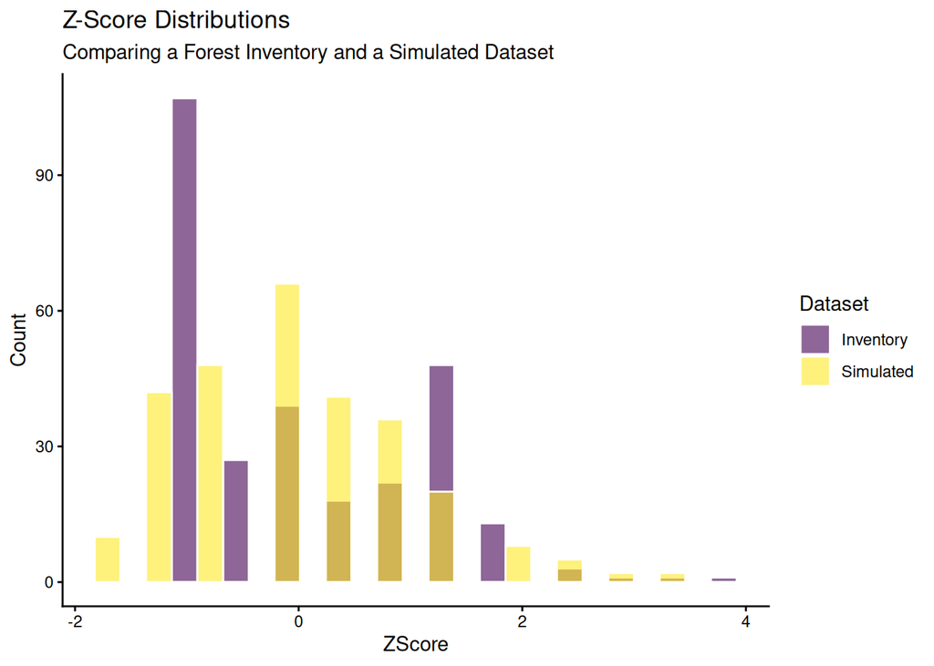

```r
bias_hist <- bias_mod1 |>
  select(TotalTimesInventoried, ZScore) |>
  rename(Count = TotalTimesInventoried) |>
  mutate(Dataset = "Inventory")

sim_hist <- sim_mod1 |>
  rename(Count = Simulated) |>
  mutate(Dataset = "Simulated")
comp_hist <- bind_rows(bias_hist,sim_hist)
comp_hist |>
    ggplot(aes(x=ZScore, fill=Dataset)) +
    geom_histogram(bins = 25, color = "white", alpha = 0.6,position = "identity") +
    scale_fill_viridis_d() +
    theme_classic() +
    labs(title="Z-Score Distributions", subtitle="Comparing a Forest Inventory and a Simulated Dataset", y="Count")
```

### Principle Component Analysis

**Objective**  
- Better understand variability within each dataset  
- Add groups beyond Plot ID to test as random factors

**Plot Dataset**

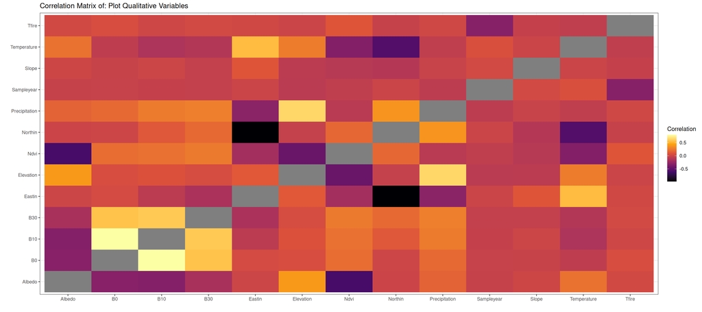

```r
library(corrr)
make_titles <- function(x){
  # expects a character or factor as an input
  stopifnot(is.character(x) | is.factor(x))

  # remove the units at the end of the name
  str_remove(x, pattern = "(g|mm)$") |>
  # replace all _ with spaces
  str_replace_all(pattern = "_", replacement = " ") |>
  # remove extra whitespace on left
  str_trim(side = "both") |>
  # convert the first letter of each word to upper case
  str_to_title()
}

cor_matrix <- function(df, title) {
  df |>
    select(where(is.numeric)) |>
    correlate(method = "pearson",
            use = "pairwise.complete.obs") |>
    rename(term1 = term) |>
    pivot_longer(cols = -term1,
               names_to = "term2",
               values_to = "correlation") |>
    mutate(
      across(.cols = c(term1, term2),
           .fns = ~ make_titles(.x)
           )
    ) |>
    ggplot(mapping = aes(x = term1,
                       y = term2,
                       fill = correlation)) +
      geom_tile() +
      labs(x = "",
       y = "",
       title = paste("Correlation Matrix of:", title),
       fill = "Correlation"
       ) +
      theme_bw() +
      scale_fill_viridis_c(option = "B")

}

plot_meta <- load_plot()

cor_matrix(plot_meta, "Plot Qualitative Variables")
```

```
Importance of components:
                          PC1    PC2    PC3    PC4     PC5     PC6    PC7
Standard deviation     1.7643 1.5456 1.4225 1.1588 1.01831 0.86853 0.8030
Proportion of Variance 0.2394 0.1838 0.1557 0.1033 0.07977 0.05803 0.0496
Cumulative Proportion  0.2394 0.4232 0.5789 0.6822 0.76193 0.81996 0.8696
                           PC8     PC9   PC10    PC11    PC12    PC13
Standard deviation     0.73070 0.69100 0.5563 0.43490 0.41475 0.11755
Proportion of Variance 0.04107 0.03673 0.0238 0.01455 0.01323 0.00106
Cumulative Proportion  0.91063 0.94735 0.9712 0.98571 0.99894 1.00000
```

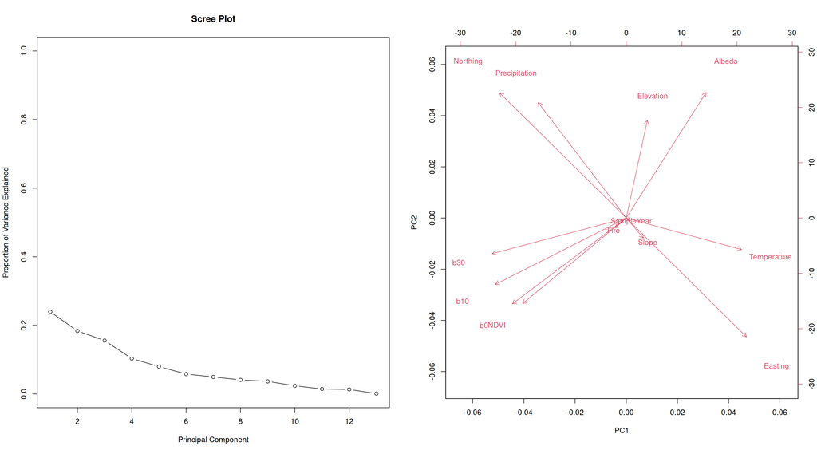

```r
# only numeric cols, will auto scale, center and return transformed data
pca_me <- function(df) {
  df1 <- df |>
    ungroup() |>
    select(where(is.numeric)) |>
    drop_na()
  pca <- prcomp(df1, scale. = TRUE, center = TRUE, retx = TRUE)

  pca_var <- pca$sdev^2
  propve <- pca_var / sum(pca_var)
  print(summary(pca))

  par(mfrow = c(1,2))
  plot(propve, xlab = "Principal Component",
     ylab = "Proportion of Variance Explained",
     ylim = c(0, 1), type = "b", main = "Scree Plot")

  biplot(pca, xlabs=rep("", nrow(df1)))

}


pca_me(plot_meta)
```

**Tree Dataset**

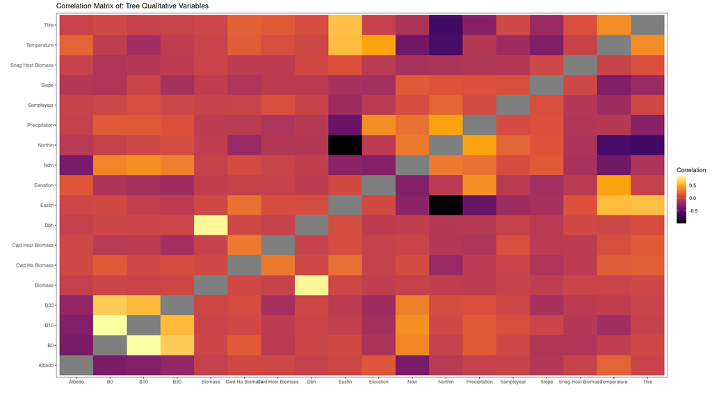

```r
tree <- load_meta()

cor_matrix(tree, "Tree Qualitative Variables")
```

```
Importance of components:
                          PC1    PC2    PC3     PC4     PC5     PC6     PC7
Standard deviation     1.9358 1.6811 1.3491 1.29724 1.16994 0.99819 0.98630
Proportion of Variance 0.2082 0.1570 0.1011 0.09349 0.07604 0.05536 0.05404
Cumulative Proportion  0.2082 0.3652 0.4663 0.55980 0.63584 0.69120 0.74524
                           PC8     PC9    PC10   PC11    PC12    PC13    PC14
Standard deviation     0.95373 0.90218 0.81506 0.7696 0.66344 0.61911 0.52252
Proportion of Variance 0.05053 0.04522 0.03691 0.0329 0.02445 0.02129 0.01517
Cumulative Proportion  0.79578 0.84099 0.87790 0.9108 0.93526 0.95655 0.97172
                          PC15    PC16    PC17    PC18
Standard deviation     0.47978 0.40947 0.31900 0.09724
Proportion of Variance 0.01279 0.00931 0.00565 0.00053
Cumulative Proportion  0.98451 0.99382 0.99947 1.00000
```

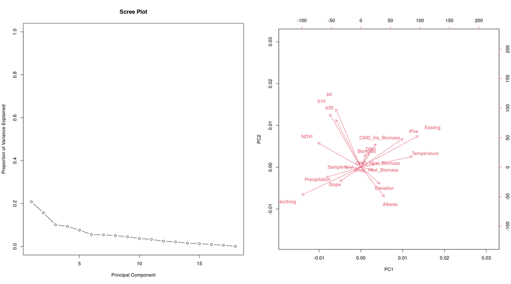

```r
pca_me(tree)
```

**Living Biomass Dataset**

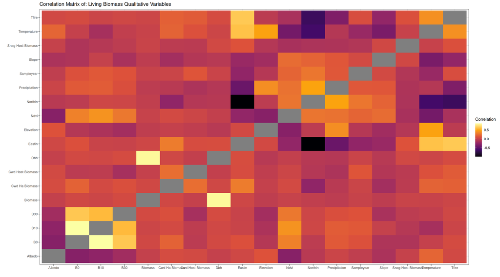

```r
live <- tree |>
  filter(Status == "L")

cor_matrix(live, "Living Biomass Qualitative Variables")
```

```
Importance of components:
                          PC1    PC2    PC3     PC4     PC5     PC6     PC7
Standard deviation     1.9478 1.6955 1.3590 1.30020 1.17374 0.99653 0.96729
Proportion of Variance 0.2108 0.1597 0.1026 0.09392 0.07654 0.05517 0.05198
Cumulative Proportion  0.2108 0.3705 0.4731 0.56700 0.64354 0.69871 0.75069
                           PC8     PC9    PC10    PC11    PC12    PC13    PC14
Standard deviation     0.94083 0.90105 0.81421 0.75408 0.66984 0.58927 0.52018
Proportion of Variance 0.04918 0.04511 0.03683 0.03159 0.02493 0.01929 0.01503
Cumulative Proportion  0.79987 0.84497 0.88180 0.91339 0.93832 0.95761 0.97264
                         PC15    PC16    PC17    PC18
Standard deviation     0.4705 0.39817 0.32228 0.09324
Proportion of Variance 0.0123 0.00881 0.00577 0.00048
Cumulative Proportion  0.9849 0.99375 0.99952 1.00000
```

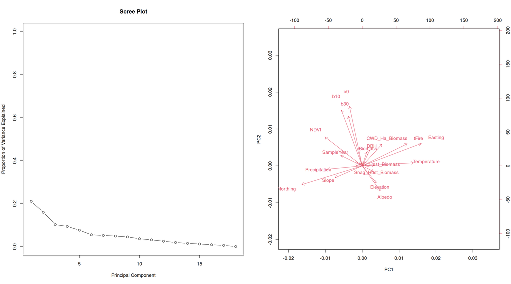

```r
pca_me(live)
```

**Standing Dead Biomass**

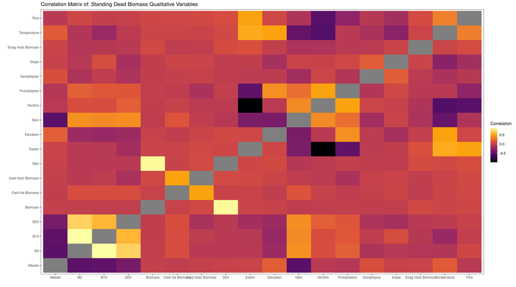

```r
dead <- tree |>
  filter(!Status == "L")

cor_matrix(dead, "Standing Dead Biomass Qualitative Variables")
```

```
Importance of components:
                          PC1    PC2    PC3    PC4     PC5    PC6     PC7
Standard deviation     1.9703 1.6256 1.3728 1.3200 1.21544 1.0623 1.00100
Proportion of Variance 0.2157 0.1468 0.1047 0.0968 0.08207 0.0627 0.05567
Cumulative Proportion  0.2157 0.3625 0.4672 0.5640 0.64605 0.7087 0.76442
                           PC8     PC9    PC10    PC11   PC12    PC13    PC14
Standard deviation     0.94021 0.86298 0.78768 0.72693 0.6293 0.59564 0.51008
Proportion of Variance 0.04911 0.04137 0.03447 0.02936 0.0220 0.01971 0.01445
Cumulative Proportion  0.81353 0.85490 0.88937 0.91873 0.9407 0.96044 0.97489
                          PC15    PC16    PC17    PC18
Standard deviation     0.46704 0.36773 0.29598 0.10462
Proportion of Variance 0.01212 0.00751 0.00487 0.00061
Cumulative Proportion  0.98701 0.99452 0.99939 1.00000
```

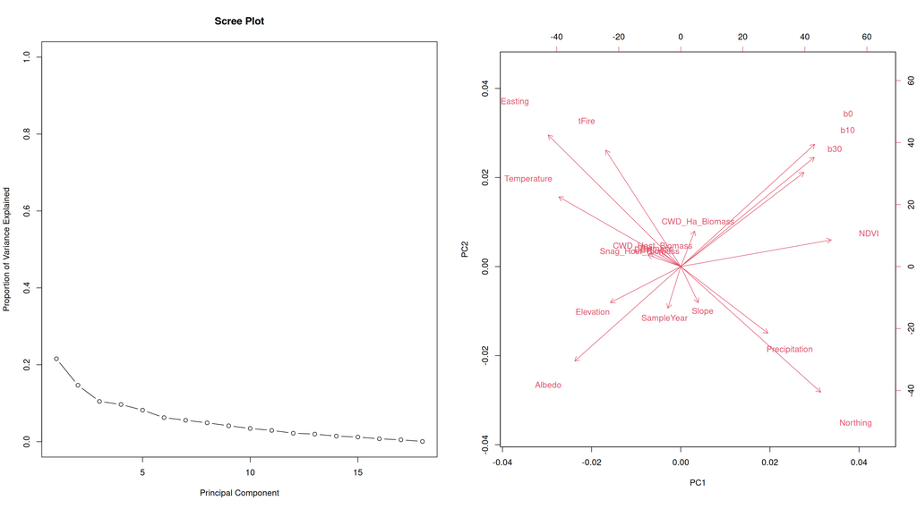

```r
pca_me(dead)
```

**Coarse woody debris biomass**

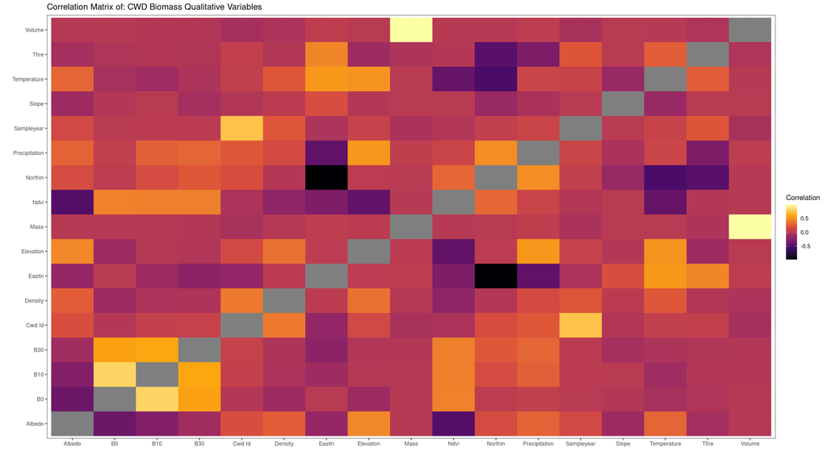

```r
cwd <- load_cwd() |>
  left_join(load_plot(), by = c("SampleYear", "Plot"), relationship = "many-to-many")



cor_matrix(cwd, "CWD Biomass Qualitative Variables")
```

```
Importance of components:
                          PC1    PC2    PC3    PC4     PC5     PC6     PC7
Standard deviation     1.8899 1.7442 1.4729 1.4017 1.27740 1.04000 0.87840
Proportion of Variance 0.2101 0.1789 0.1276 0.1156 0.09599 0.06362 0.04539
Cumulative Proportion  0.2101 0.3891 0.5167 0.6322 0.72821 0.79184 0.83722
                           PC8     PC9    PC10    PC11    PC12    PC13    PC14
Standard deviation     0.81366 0.76998 0.62642 0.56809 0.50056 0.47172 0.41405
Proportion of Variance 0.03894 0.03487 0.02308 0.01898 0.01474 0.01309 0.01008
Cumulative Proportion  0.87617 0.91104 0.93412 0.95311 0.96785 0.98094 0.99102
                          PC15    PC16    PC17
Standard deviation     0.37020 0.11379 0.05159
Proportion of Variance 0.00806 0.00076 0.00016
Cumulative Proportion  0.99908 0.99984 1.00000
```

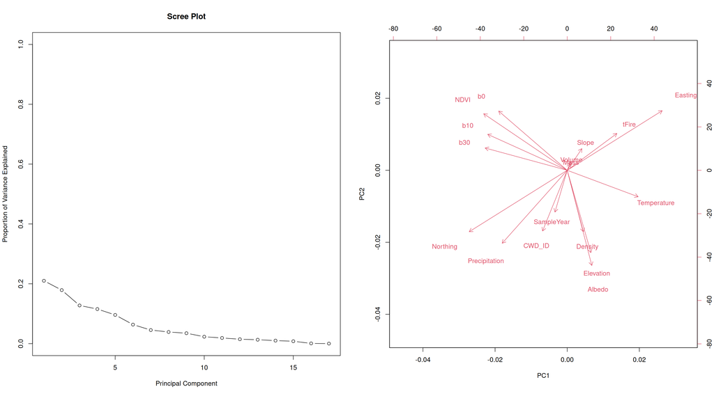

```r
pca_me(cwd)
```

### Analysis of State Factor’s Influence on Forest Type

Aim to answer:

**Which state factors drive forest type?**  
**How does logistic regression compare to random forest models?**

#### Logistic Regression

```r
library(car)
library(pROC)
state <- load_plot()

state_model1 <- glm(ForestType ~ grtgroup + b0 + b10 + b30 + Precipitation + Temperature +
                    NDVI + Albedo + Elevation + Slope + Easting +
                    Northing, data = state, family = "binomial")

log_vis <- summary(state_model1)
print(log_vis)
```

```
Call:
glm(formula = ForestType ~ grtgroup + b0 + b10 + b30 + Precipitation +
    Temperature + NDVI + Albedo + Elevation + Slope + Easting +
    Northing, family = "binomial", data = state)

Coefficients:
                Estimate Std. Error z value Pr(>|z|)
(Intercept)   -1.383e+03  1.157e+02 -11.953  < 2e-16 ***
grtgroup215   -3.688e-01  9.071e-01  -0.407  0.68431
grtgroup228   -5.417e-01  3.972e-01  -1.364  0.17258
grtgroup273    4.784e-02  1.709e-01   0.280  0.77950
grtgroup289   -7.897e-01  2.179e-01  -3.624  0.00029 ***
b0             4.365e-01  9.923e-02   4.399 1.09e-05 ***
b10           -3.035e-02  1.021e-01  -0.297  0.76625
b30           -5.838e-01  1.265e-01  -4.617 3.90e-06 ***
Precipitation -2.286e-02  9.775e-03  -2.339  0.01935 *
Temperature    1.015e+00  1.728e-01   5.872 4.32e-09 ***
NDVI           6.043e+00  1.386e+00   4.360 1.30e-05 ***
Albedo        -1.717e+01  6.614e+00  -2.596  0.00944 **
Elevation     -8.890e-03  6.033e-04 -14.736  < 2e-16 ***
Slope          5.151e-02  9.211e-03   5.592 2.25e-08 ***
Easting        3.412e-04  2.905e-05  11.744  < 2e-16 ***
Northing       2.890e-04  2.434e-05  11.877  < 2e-16 ***
---
Signif. codes:  0 '***' 0.001 '**' 0.01 '*' 0.05 '.' 0.1 ' ' 1

(Dispersion parameter for binomial family taken to be 1)

    Null deviance: 2799.1  on 2021  degrees of freedom
Residual deviance: 1672.3  on 2006  degrees of freedom
  (71 observations deleted due to missingness)
AIC: 1704.3

Number of Fisher Scoring iterations: 6
```

```r
print(vif(state_model1))
```

```
                   GVIF Df GVIF^(1/(2*Df))
grtgroup       1.637303  4        1.063570
b0             3.934981  1        1.983679
b10            3.861055  1        1.964957
b30            1.860172  1        1.363881
Precipitation  2.809278  1        1.676090
Temperature    2.778740  1        1.666955
NDVI           2.301581  1        1.517096
Albedo         1.725540  1        1.313598
Elevation      2.901414  1        1.703354
Slope          1.140343  1        1.067868
Easting       40.446228  1        6.359735
Northing      47.365541  1        6.882263
```

```r
log_pred <- predict(state_model1, type = "response")
roc_obj <- roc(state_model1$model$ForestType, log_pred, quiet = TRUE)
auc_val <- as.numeric(auc(roc_obj))
print(paste("ROC: ", round(auc_val, 3)))
```

```
[1] "ROC:  0.896"
```

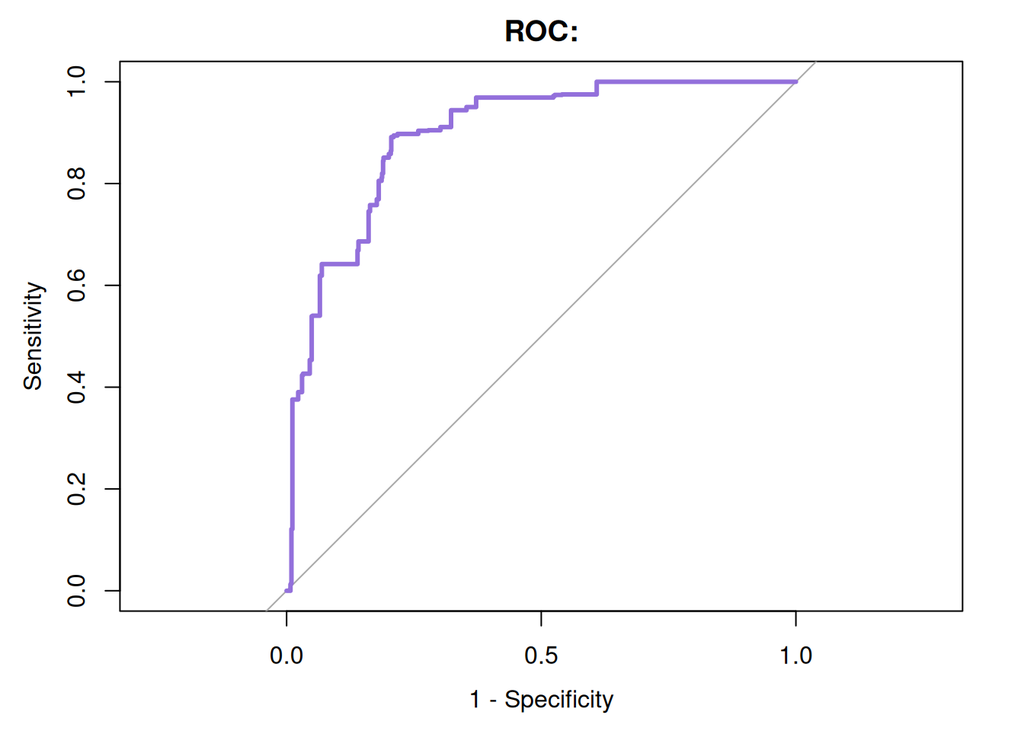

```r
plot(roc_obj, main = "ROC:",
     col = "#9370DB", lwd = 3, legacy.axes = TRUE) + theme_bw()
```

#### Random forest classification model

```r
library(ranger)
library(vip)
vars_used <- c("ForestType","grtgroup","b0","b10","b30","Precipitation",
               "Temperature","NDVI","Albedo","Elevation","Slope","Easting","Northing")

state_cc <- state[complete.cases(state[, vars_used]), ]

set.seed(200)
train_index <- sample(1:nrow(state_cc), 0.8 * nrow(state_cc))
train <- state_cc[train_index, ]
test  <- state_cc[-train_index, ]

rf_model <- ranger(ForestType ~ grtgroup + b0 + b10 + b30 + Precipitation + Temperature +
                    NDVI + Albedo + Elevation + Slope + Easting +
                    Northing, data = train,
                   num.trees = 100,
                    importance = "permutation"
)

prediction <- predict(rf_model, data = test)$predictions

rmse_rf <- sqrt(rf_model$prediction.error)

accuracy <- mean(prediction == test$ForestType)
print(paste("Accuracy:", accuracy))
```

```
[1] "Accuracy: 0.997530864197531"
```

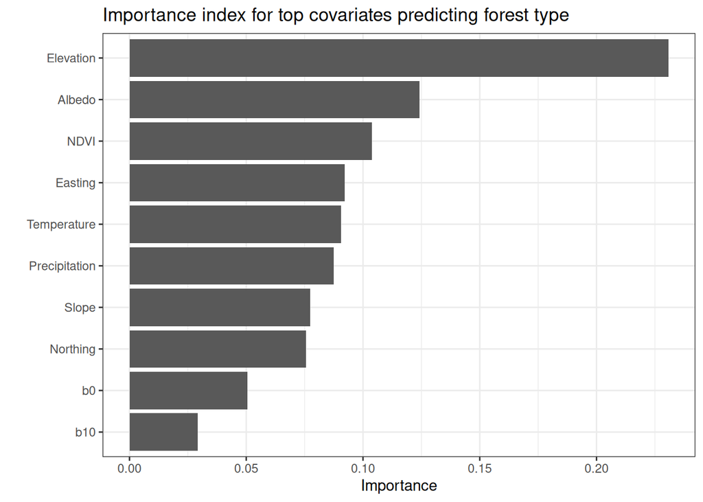

```r
p1 <- vip::vip(rf_model) + theme_bw() + labs(title = "Importance index for top covariates predicting forest type")
print(p1)
```

```r
roc_rf <- roc(test$ForestType, as.numeric(prediction), quiet = TRUE)
auc_rf <- as.numeric(auc(roc_rf))
print(paste("ROC: ", round(auc_rf, 3)))
```

```
[1] "ROC:  0.997"
```

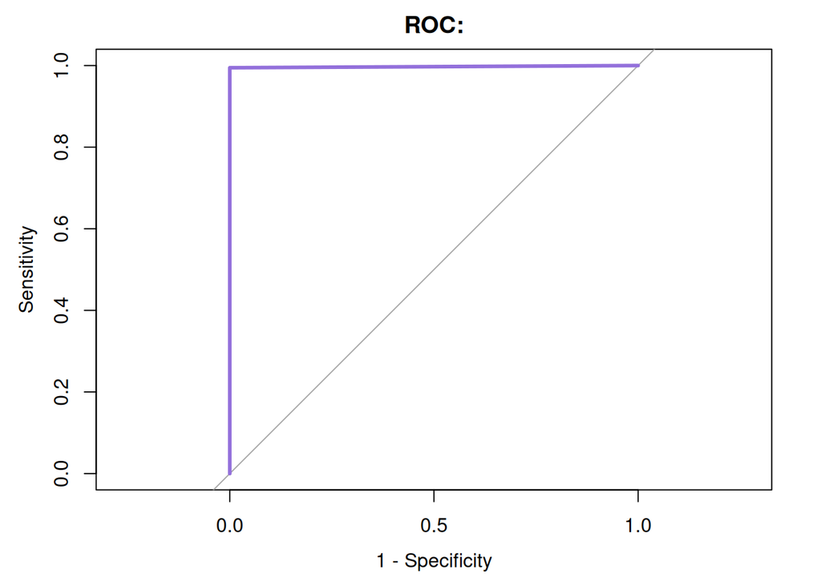

```r
plot(roc_rf, main = "ROC:",
     col = "#9370DB", lwd = 3, legacy.axes = TRUE)
```

**How do the logistic and Random forest models compare?**

- Utilizing auc

```r
comps <- tibble(
                   Model = c("Logistic Regression", "Random Forest"),
                             AUC = c(auc_val, auc_rf)) |>
gt() |>
fmt_number(decimals = 2)

comps
```

| Model | AUC |
| --- | --- |
| Logistic Regression | 0.90 |
| Random Forest | 1.00 |

### Understanding stand density and biomass distributions

##### Across all the data

```r
t <- load_tree() |> filter(Species %in% c("SESE", "LIDE", "QUAG", "UMCA"))
p <- load_plot() |> select(Plot, SampleYear, Elevation, Slope, BurnScar, PRam, Fire, tFire, ForestType)

q <- left_join(t, p, by = c("Plot", "SampleYear")) |> distinct()

q_sums <- q |>

  group_by(Plot, Species, SampleYear, Status, PRam, Fire, ForestType) |>
  mutate(Status = case_when(
                            Status == "L" ~ 0,
                            TRUE ~ 1)) |>
  summarize(TotalStem = n(),
            TotalBiomass = sum(Biomass, na.rm = TRUE)) |>
  distinct()

no_empty_dis <- q_sums |> filter(TotalStem > 0 & TotalBiomass > 0)

box_cox <- function(dfCol){
  pt <- orderNorm(dfCol)

  n <- pt$x.t
  return(n)
}

no_empty_dis$BCTotalBiomass <- box_cox(no_empty_dis$TotalBiomass)
no_empty_dis$BCTotalStem <- box_cox(no_empty_dis$TotalStem)


p_total <- function(df) {
  df |>
   group_by(Plot, SampleYear, ForestType, Status) |>
   summarize(TotalStem = sum(TotalStem, na.rm = TRUE),
             TotalBiomass = sum(TotalBiomass, na.rm = TRUE))

}

totals <- p_total(no_empty_dis)

totals$BCTotalStem <- box_cox(totals$TotalStem)
totals$BCTotalBiomass <- box_cox(totals$TotalBiomass)


normal <- function(df, stat, metric_need = TRUE, metric = NULL, status = NULL) {

  if (metric_need) {
    df1 <- df |> filter(ForestType == metric & Status == status)
  } else {
    df1 <- df
  }

  stat_vec <- df1 |> pull({{ stat }})
  stat_vec <- na.omit(stat_vec)

  a <- df1 |>
    ggplot(aes(x = {{ stat }})) +
    geom_histogram(aes(y = after_stat(density)), fill = "gray80", color = "black") +
    geom_density(color = "darkred", linewidth = 1, adjust = 1) +
    theme_bw() +
    labs(title = "Is the data normal?")

  n_obs <- length(stat_vec)

  if (n_obs >= 3 && n_obs <= 5000) {
    b <- shapiro.test(stat_vec)
    p_val_b <- b$p.value
    lbl <- if (p_val_b <= 0.1) "** Not normal" else "* Normally Distributed"

    a1 <- a + annotate(
      "text",
      x = min(stat_vec, na.rm = TRUE),
      y = Inf,
      label = paste0(lbl, " (p = ", round(p_val_b, 3), ")"),
      vjust = 2,
      hjust = 0,
      size = 4,
      fontface = "bold"
    )
  } else if (n_obs > 5000) {

    a1 <- a
  } else {
    a1 <- a + labs(subtitle = "N < 3: Insufficient data for Shapiro-Wilk test")
  }

  a2 <- df1 |>
    ggplot(aes(sample = {{ stat }})) +
    stat_qq() +
    stat_qq_line(color = "darkred", linewidth = 1) +
    theme_bw() +
    labs(title = "Q-Q Plot", x = "Theoretical Quantiles", y = "Sample Quantiles")

  a_final <- a1 / a2
  return(a_final)
}
```

**For live biomass in mixed evergreen forests**

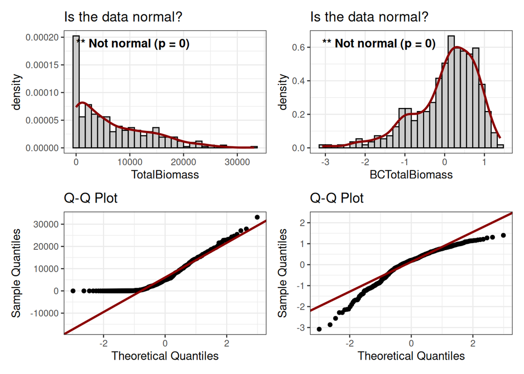

```r
bio <- normal(totals, metric_need = TRUE, metric = 1, status = 0, stat = TotalBiomass)
bio_bc <- normal(totals,  metric_need = TRUE, metric = 1, status = 0, stat = BCTotalBiomass)

bio | bio_bc
```

**For dead biomass in mixed evergreen forests**

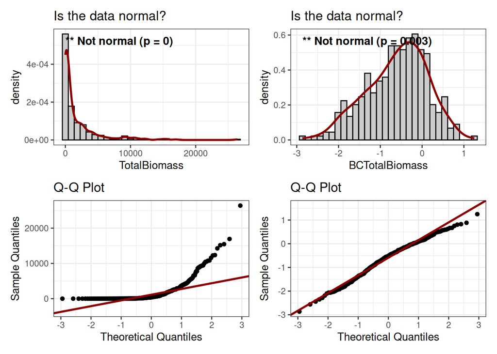

```r
bio_dead <- normal(totals,  metric_need = TRUE, metric = 1, status = 1, stat = TotalBiomass)
bio_bc_dead <- normal(totals, metric_need = TRUE, metric = 1, status =  1, stat = BCTotalBiomass)

bio_dead | bio_bc_dead
```

**For living biomass in redwood forests**

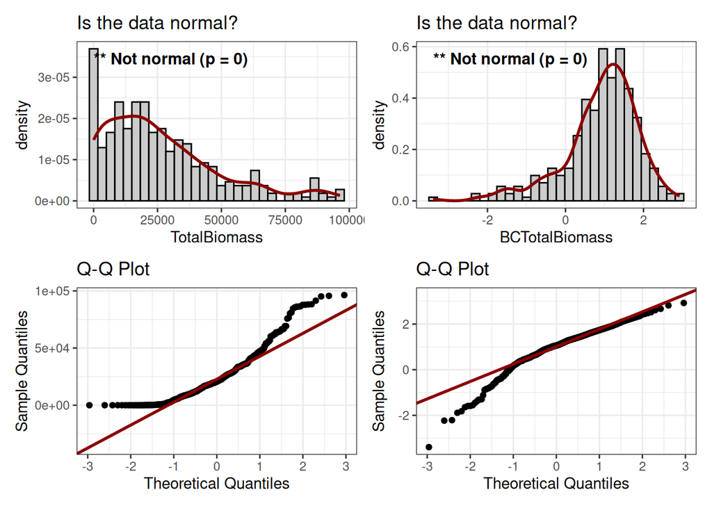

```r
bio <- normal(totals, metric_need = TRUE, metric = 2, status = 0, stat = TotalBiomass)
bio_bc <- normal(totals, metric_need = TRUE, metric = 2, status = 0, stat = BCTotalBiomass)

bio | bio_bc
```

**For dead biomass in redwood forests**

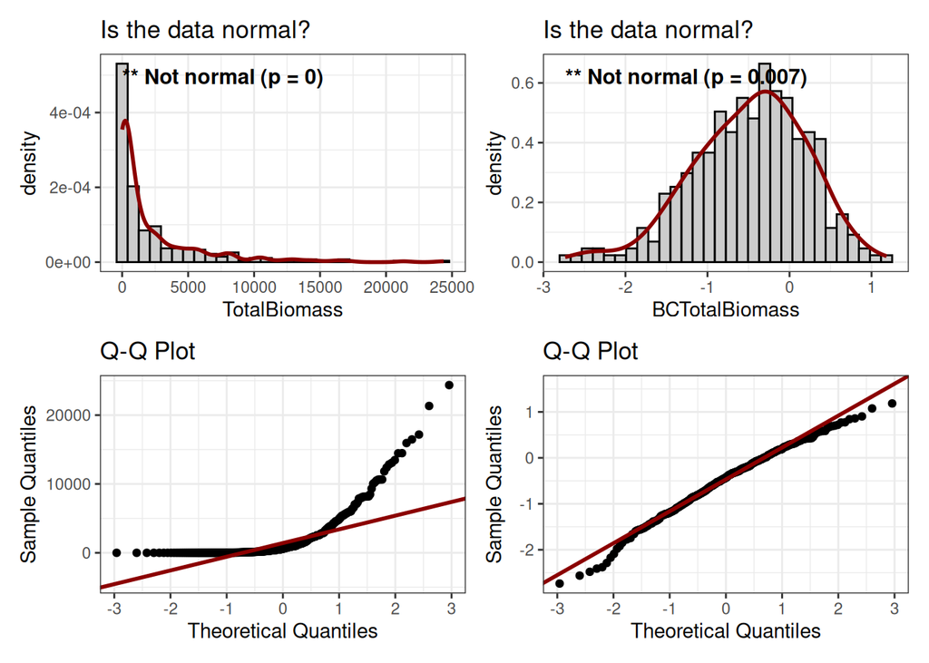

```r
bio_dead <- normal(totals, metric_need = TRUE, metric = 2, status = 1, stat = TotalBiomass)
bio_bc_dead <- normal(totals, metric = 2, status = 1, stat = BCTotalBiomass)

bio_dead | bio_bc_dead
```

##### Across snag host biomass

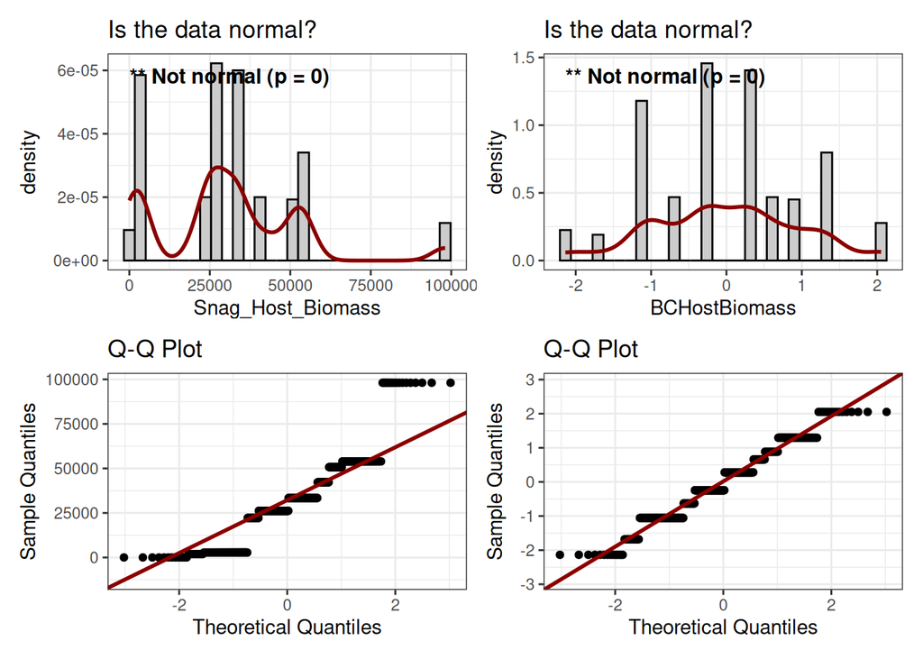

```r
m <- load_meta() |> select(Plot, SampleYear, Snag_Host_Biomass) |>
  select(Plot, SampleYear, Snag_Host_Biomass) |>
  filter(Snag_Host_Biomass > 0)

m$BCHostBiomass <- box_cox(m$Snag_Host_Biomass)

m_dead    <- normal(m, metric_need = FALSE, stat = Snag_Host_Biomass)
m_bc_dead <- normal(m, metric_need = FALSE, stat = BCHostBiomass)

# Combine side-by-side
m_dead | m_bc_dead
```

##### Across cwd host biomass

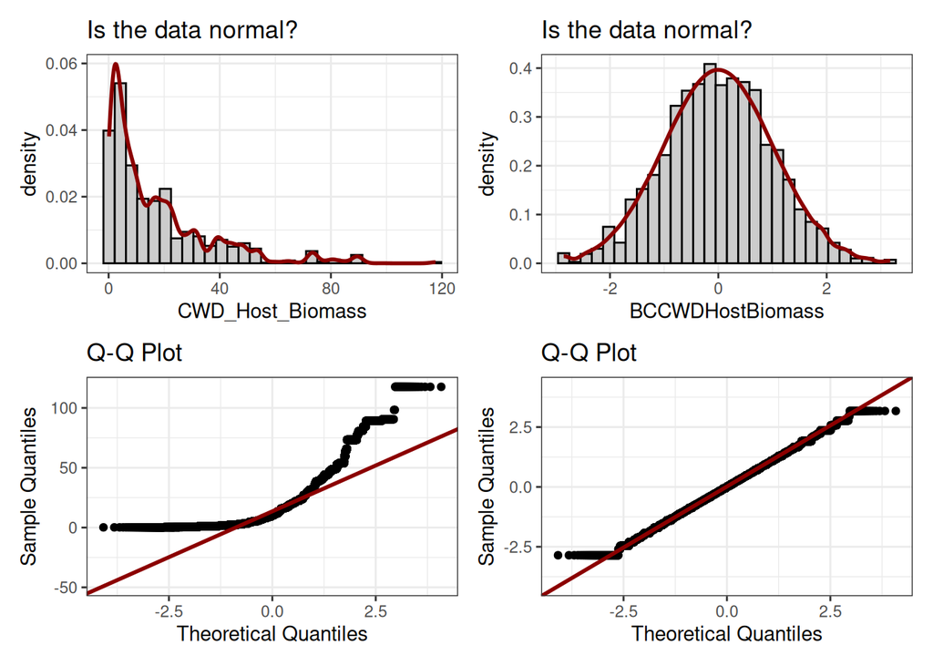

```r
m <- load_meta() |> select(Plot, SampleYear, CWD_Host_Biomass) |>
  select(Plot, SampleYear, CWD_Host_Biomass) |>
  filter(CWD_Host_Biomass > 0)

m$BCCWDHostBiomass <- box_cox(m$CWD_Host_Biomass)

m_dead    <- normal(m, metric_need = FALSE, stat = CWD_Host_Biomass)
m_bc_dead <- normal(m, metric_need = FALSE, stat = BCCWDHostBiomass)

# Combine side-by-side
m_dead | m_bc_dead
```

#### Across redwood biomass

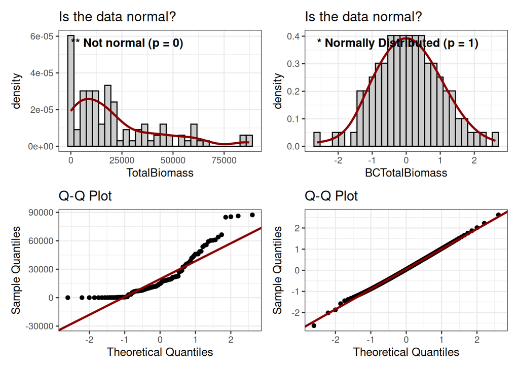

```r
species <- no_empty_dis |>
  select(Plot, Species, SampleYear, Status, ForestType, TotalStem, TotalBiomass) |>
  inner_join(m, by = c("Plot", "SampleYear")) |>
  distinct()


sese <- species |>
 filter(Species == "SESE" & Status == 0)

sese$BCTotalBiomass <- box_cox(sese$TotalBiomass)

sese_live    <- normal(sese, metric_need = TRUE, metric = 2, status = 0, stat = TotalBiomass)
sese_bc_live <- normal(sese, metric_need = TRUE, metric = 2, status = 0, stat = BCTotalBiomass)

# Combine side-by-side
sese_live | sese_bc_live
```

#### Across LIDE stem densities

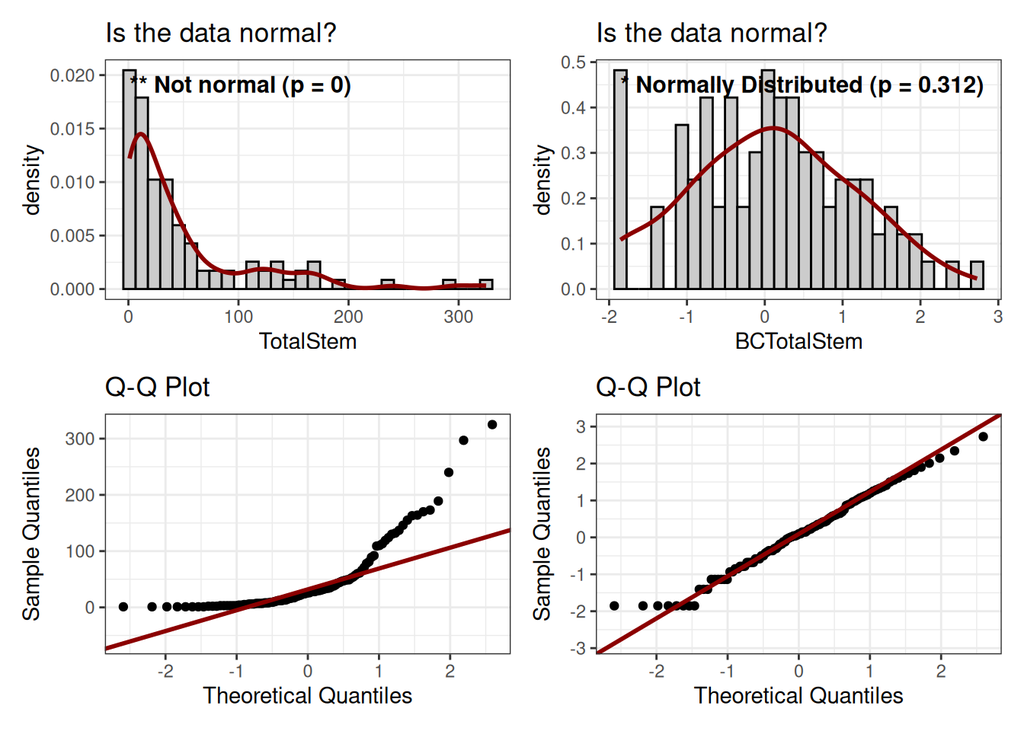

```r
lide <- species |>
 filter(Species == "LIDE" & Status == 0) |>
 rename(LideSnagBiomass = TotalBiomass)

lide$BCTotalStem <- box_cox(lide$TotalStem)
lide$LideSnagBiomassNorm <- box_cox(lide$LideSnagBiomass)

lide_live    <- normal(lide, metric_need = TRUE, metric = 2, status = 0, stat = TotalStem)
lide_bc_live <- normal(lide, metric_need = TRUE, metric = 2, status = 0, stat = BCTotalStem)

# Combine side-by-side
lide_live | lide_bc_live
```

```r
lide2 <- lide |>
  ungroup() |>
  filter(Status == 0) |>
  select(Plot, SampleYear, PRam, Fire, LideSnagBiomass, LideSnagBiomassNorm)
```

#### Across UMCA stem densities

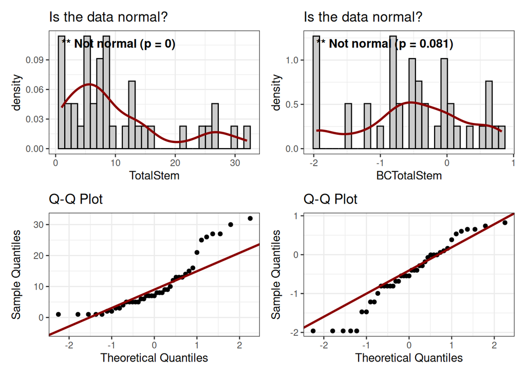

```r
umca <- species |>
 filter(Species == "UMCA")

umca$BCTotalStem <- box_cox(umca$TotalStem)

umca_live    <- normal(umca, metric_need = TRUE, metric = 2, status = 0, stat = TotalStem)
umca_bc_live <- normal(umca , metric_need = TRUE, metric = 2, status = 0, stat = BCTotalStem)

# Combine side-by-side
umca_live | umca_bc_live
```

```r
umca2 <- umca |>
  ungroup() |>
  filter(Status == 0) |>
  select(Plot, SampleYear, PRam, Fire, TotalStem, BCTotalStem) |>
  rename(UmcaTotalStem = TotalStem,
         BCUmcaTotalStem = BCTotalStem)
```

#### Final dataset

```r
sese_final <- sese |>
  left_join(umca2, by = c("Plot", "SampleYear", "PRam", "Fire")) |>
  left_join(lide2, by = c("Plot", "SampleYear", "PRam", "Fire")) |>
  ungroup() |>
  mutate(across(c("PRam", "Fire"), as.numeric)) |>
  left_join(p |> select(Plot, Elevation, Slope, BurnScar),
                        by = "Plot") |>
  rename(CwdHostBiomassNorm = BCCWDHostBiomass,
         SeseBiomassNorm = BCTotalBiomass,
        UmcaStemDensityNorm = BCUmcaTotalStem)
```

### Disease and fire impacts on redwood living biomass

#### Path Analysis

Testing the following word equations:

$$Redwood living biomass = Tanoak Snag Biomass + Cwd Biomass + Fire + Disease + Elevation + Slope$$

$$Tanoak Snag Biomass = Bay Laurel Density + Disease$$

$$Cwd Biomass = Tanoak Snag Biomass + Bay Laurel Density + Fire + Disease$$

```r
intro <- "SeseBiomassNorm ~ CwdHostBiomassNorm + LideSnagBiomassNorm + Fire + PRam + Elevation + Slope
          LideSnagBiomassNorm ~ UmcaStemDensityNorm + PRam
          CwdHostBiomassNorm ~ UmcaStemDensityNorm + LideSnagBiomassNorm + PRam + Fire
          "

fit <- sem(model = intro, data = sese_final)

library(semPlot)

summary(fit, rsquare = TRUE, fit.measures = TRUE)
```

```
lavaan 0.7-2 ended normally after 1 iteration

  Estimator                                         ML
  Optimization method                           NLMINB
  Number of model parameters                        15

                                                  Used       Total
  Number of observations                           404        1656

Model Test User Model:

  Test statistic                                21.314
  Degrees of freedom                                 6
  P-value (Chi-square)                           0.002

Model Test Baseline Model:

  Test statistic                               600.528
  Degrees of freedom                                18
  P-value                                        0.000

User Model versus Baseline Model:

  Comparative Fit Index (CFI)                    0.974
  Tucker-Lewis Index (TLI)                       0.921

Loglikelihood and Information Criteria:

  Loglikelihood user model (H0)              -1175.663
  Loglikelihood unrestricted model (H1)      -1165.006

  Akaike (AIC)                                2381.326
  Bayesian (BIC)                              2441.347
  Sample-size adjusted Bayesian (SABIC)       2393.750

Root Mean Square Error of Approximation:

  RMSEA                                          0.079
  90 Percent confidence interval - lower         0.045
  90 Percent confidence interval - upper         0.117
```

[output cut: 33 more lines]

```
    LideSngBmssNrm          0.288    0.056    5.113    0.000
    PRam                    0.501    0.114    4.394    0.000
    Fire                   -0.500    0.115   -4.355    0.000

Variances:
                   Estimate   Std.Err  z-value  P(>|z|)
   .SeseBiomassNrm     0.148    0.010   14.213    0.000
   .LideSngBmssNrm     0.599    0.042   14.213    0.000
   .CwdHostBmssNrm     0.765    0.054   14.213    0.000

R-Square:
                   Estimate
    SeseBiomassNrm     0.663
    LideSngBmssNrm     0.112
    CwdHostBmssNrm     0.171
```

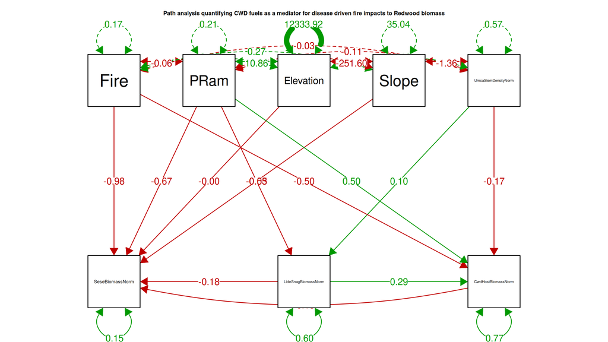

```r
#png("./exports/sese-path.png", width = 1400, height = 1000, res = 150)
par(mar = c(1, 1, 6, 1))

semPaths(fit, what = "est", fade = FALSE, edge.label.cex = 0.8,
         sizeMan = 10,
         nCharNodes = 0, nCharEdges = 0,
         residuals = TRUE,
         mar = c(6, 6, 8, 6))

title("Path analysis quantifying CWD fuels as a mediator for disease driven fire impacts to Redwood biomass",
      line = 4, cex.main = 0.9)
```

```r
#dev.off()
```

#### Mixed effects modeling

Using the following word equation:

$$Redwood living biomass = Tanoak Snag Biomass + Cwd Biomass + Fire + Disease + Elevation + Slope + (1 | Plot) + (1 |SampleYear)$$

```r
bio_mixed <- lmer(
                  SeseBiomassNorm ~ CwdHostBiomassNorm + LideSnagBiomassNorm + Fire + PRam + Elevation + Slope  +
                    (1 | Plot) + (1 |SampleYear),
                  data = sese_final)

summary(bio_mixed)
```

```
Linear mixed model fit by REML. t-tests use Satterthwaite's method [
lmerModLmerTest]
Formula: SeseBiomassNorm ~ CwdHostBiomassNorm + LideSnagBiomassNorm +
    Fire + PRam + Elevation + Slope + (1 | Plot) + (1 | SampleYear)
   Data: sese_final

REML criterion at convergence: -158.2

Scaled residuals:
     Min       1Q   Median       3Q      Max
-1.95731 -0.56798 -0.01911  0.51742  2.87083

Random effects:
 Groups     Name        Variance Std.Dev.
 Plot       (Intercept) 0.89907  0.9482
 SampleYear (Intercept) 0.22851  0.4780
 Residual               0.04186  0.2046
Number of obs: 1469, groups:  Plot, 44; SampleYear, 7

Fixed effects:
                      Estimate Std. Error         df t value Pr(>|t|)
(Intercept)          1.962e+00  1.318e+00  4.109e+01   1.489   0.1440
CwdHostBiomassNorm   4.570e-02  1.122e-02  1.438e+03   4.075 4.85e-05 ***
LideSnagBiomassNorm  1.916e-01  1.353e-02  1.444e+03  14.161  < 2e-16 ***
Fire                -8.781e-01  4.309e-01  3.944e+01  -2.038   0.0483 *
PRam                 4.246e-01  4.349e-02  1.450e+03   9.763  < 2e-16 ***
Elevation            6.088e-04  1.250e-03  3.954e+01   0.487   0.6288
Slope               -4.039e-02  2.031e-02  3.963e+01  -1.988   0.0537 .
---
Signif. codes:  0 '***' 0.001 '**' 0.01 '*' 0.05 '.' 0.1 ' ' 1

Correlation of Fixed Effects:
            (Intr) CwdHBN LdSnBN Fire   PRam   Elevtn
CwdHstBmssN  0.008
LdSngBmssNr -0.007  0.437
Fire        -0.688  0.005  0.012
PRam        -0.040 -0.043  0.164 -0.001
Elevation   -0.677 -0.003  0.005  0.231  0.002
Slope       -0.565 -0.013 -0.017 -0.033 -0.032  0.265
```

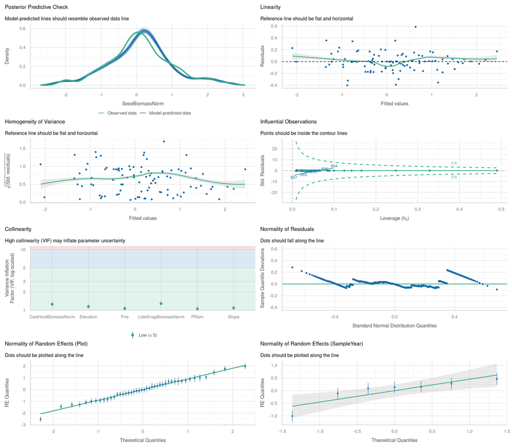

```r
check_model(bio_mixed)
```

##### How do the models compare?

```r
comp_me <- function(m1, m2, title1, title2) {
  df <- data.frame(
                   Model = c(title1, title2),
                   AIC = c(AIC(m1), AIC(m2))) |>
  gt()

  return(df)

}



comp_me(m1 = fit, m2 = bio_mixed, title1 = "Path analysis", title2 = "Mixed effects model")
```

| Model | AIC |
| --- | --- |
| Path analysis | 2381.3255 |
| Mixed effects model | -138.2327 |

#### Survival analysis

Using the following word equation:

$$Redwood stem mortality = Tanoak Snag Biomass + Cwd Biomass + DBH + Fire + Disease + Elevation + Slope + t$$

```r
sese_stem <- t |> filter(Species == "SESE") |>
  rename(status = Mortality) |>
  mutate(status = case_when(
                            status == 0 ~ 1,
                            TRUE ~ 2),
  t = SampleYear - 2006) |>
  select(Plot, Species, SampleYear, DBH, status, t)


sese_plot <- sese_final |>
  select(Plot, SampleYear, Fire, PRam, CwdHostBiomassNorm, LideSnagBiomassNorm, Elevation,  Slope)


sese_sa <- left_join(sese_plot, sese_stem, by = c("Plot", "SampleYear"))

library(survival)
library(survminer)

f <- Surv(t, status) ~ CwdHostBiomassNorm + LideSnagBiomassNorm + Fire + DBH + PRam + Elevation + Slope

fits <- list(
  exponential   = survreg(f, data = sese_sa, dist = "exponential"),
  weibull       = survreg(f, data = sese_sa, dist = "weibull"),
  lognormal     = survreg(f, data = sese_sa, dist = "lognormal"),
  loglogistic   = survreg(f, data = sese_sa, dist = "loglogistic")
)

aic <- sapply(fits, AIC)
tab <- data.frame(distribution = names(aic), AIC = round(aic, 1))
tab <- tab[order(tab$AIC), ]
tab$delta_AIC <- round(tab$AIC - min(tab$AIC), 1)

tab |>
  gt()
```

| distribution | AIC | delta_AIC |
| --- | --- | --- |
| weibull | 96079.8 | 0.0 |
| loglogistic | 96268.8 | 189.0 |
| lognormal | 97149.0 | 1069.2 |
| exponential | 108185.2 | 12105.4 |

```r
exp_sa <- survreg(f, data = sese_sa, dist = "weibull")


summary(exp_sa)
```

```
Call:
survreg(formula = f, data = sese_sa, dist = "weibull")
                        Value Std. Error       z       p
(Intercept)          3.11e+00   4.18e-02   74.36 < 2e-16
CwdHostBiomassNorm   4.36e-02   3.70e-03   11.79 < 2e-16
LideSnagBiomassNorm -8.44e-02   4.60e-03  -18.36 < 2e-16
Fire                -1.60e-01   1.32e-02  -12.10 < 2e-16
DBH                  1.02e-02   3.16e-04   32.30 < 2e-16
PRam                -9.07e-03   7.19e-03   -1.26 0.20676
Elevation           -1.37e-04   3.61e-05   -3.80 0.00014
Slope                4.21e-03   6.37e-04    6.61 3.8e-11
Log(scale)          -1.03e+00   7.67e-03 -134.98 < 2e-16

Scale= 0.355

Weibull distribution
Loglik(model)= -48030.9   Loglik(intercept only)= -49617.4
    Chisq= 3172.94 on 7 degrees of freedom, p= 0
Number of Newton-Raphson Iterations: 9
n=48265 (30547 observations deleted due to missingness)
```

```r
sese_sa$PredictedTimeDeath <- predict(exp_sa, newdata = sese_sa, type = "response")
```

### Plot level living biomass changes

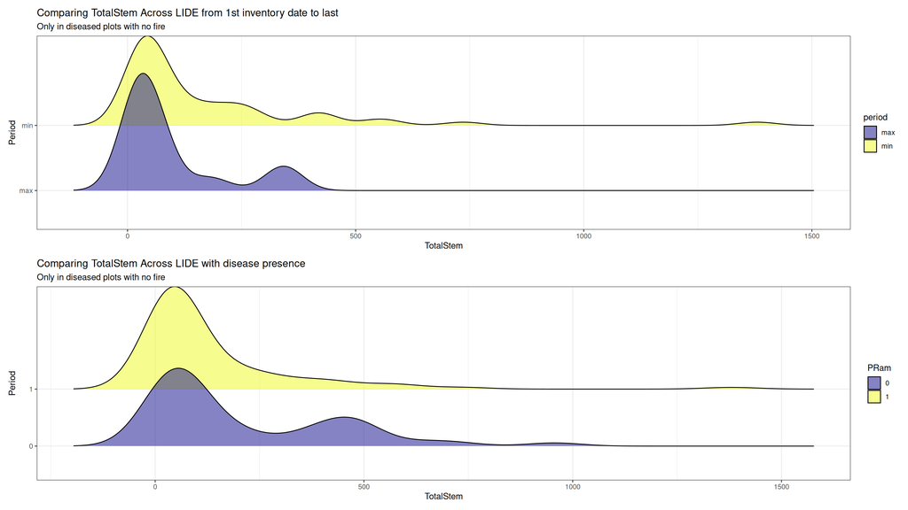

```r
t <- load_tree()
p <- load_plot() |> select(Plot, SampleYear, Elevation, Slope, BurnScar, PRam, Fire, tFire, ForestType)

q <- left_join(t, p, by = c("Plot", "SampleYear"))

q_sums <- q |>
  filter(ForestType == 2) |>
  group_by(Plot, Species, SampleYear, Status, PRam, Fire) |>
  mutate(Status = case_when(
                            Status == "L" ~ 0,
                            TRUE ~ 1)) |>
  summarize(TotalStem = n(),
            TotalBiomass = sum(Biomass, na.rm = TRUE)) |>
  distinct()


min_max <- function(df) {
  df |>
    group_by(Plot, Species) |>
    filter(SampleYear %in% c(min(SampleYear), max(SampleYear))) |>
    mutate(period = if_else(SampleYear == min(SampleYear), "min", "max")) |>
    ungroup()
}

ts_look <- function(df, species, metric) {
  disease_only <- q_sums |>
    filter(Status == 0 & Fire == 0)

  first_last <- disease_only |>
    filter(PRam == 1) |>
    min_max()


  p1 <- first_last |>
    filter(Species == species) |>
    ggplot(aes(y = period, x = .data[[metric]], fill = period)) +
    geom_density_ridges(alpha = 0.5) +
    scale_fill_viridis_d(option = "C") +
    labs(title = paste("Comparing", metric, "Across", species, "from 1st inventory date to last"),
                       subtitle = "Only in diseased plots with no fire",
                       x = metric, y = "Period", color = "Time Period") +
    theme_bw()


  p2 <- disease_only |>
    filter(Species == species) |>
    ggplot(aes(y = PRam, x = .data[[metric]], fill = PRam)) +
    geom_density_ridges(alpha = 0.5) +
    scale_fill_viridis_d(option = "C") +
    labs(title = paste("Comparing", metric, "Across", species, "with disease presence"),
                       subtitle = "Only in diseased plots with no fire",
                       x = metric, y = "Period", color = "Disease") +

    theme_bw()

  p1 / p2

}


ts_look(q_sums, "LIDE", "TotalStem")
```

```r
l <- q |>
  distinct() |>
  group_by(Plot, ForestType, SampleYear) |>
  summarize(AverageDensity =  n_distinct(StemId, na.rm = TRUE)) |>
  ungroup() |>
  drop_na(ForestType) |>
  mutate(ForestType = case_when(
                                ForestType == 1 ~ "Mixed Evergreen",
                                TRUE ~ "Redwood")) |>
  ggplot(aes(y =  ForestType, x = AverageDensity, fill = ForestType)) +
  geom_density_ridges(rel_min_height = 0.005, scale = 20, alpha = 0.5, quantile_lines = FALSE,
                      calc_ecdf = TRUE,
                      geom = "density_ridges_gradient") +
  scale_fill_viridis_d(option = "C") +
  labs(title = "Comparing Stand Density Across Forest Types", x = "Stand Density", y = "Forest Type",
  color = "Forest Type") +
  theme_bw()




p <- t |>
  filter(Species %in% c("SESE", "QUAG", "LIDE")) |>
  distinct() |>
  ggplot(aes(y = Species, x = DBH, color = Species, fill = Species)) +
  geom_density_ridges(scale = 0.6) +
  theme_bw() +
  scale_fill_viridis_d(option = "D") +
  scale_color_viridis_d(option = "D")


l_sum <- function(df, live = TRUE) {
  if (live == TRUE) {
    df |>
      filter(Status == "L" & Species %in% c('LIDE', 'SESE', 'UMCA', 'QUAG')) |>
      group_by(Plot, SampleYear, Species) |>
      summarize(LiveBiomass = sum(Biomass, na.rm = TRUE) * 20) |>
      group_by(Plot, SampleYear) |>
      mutate(TotalLiveBiomass = sum(LiveBiomass))

  } else {
    df |>
      filter(!Status == "L" & Species %in% c('LIDE', 'SESE', 'UMCA', 'QUAG')) |>
      group_by(Plot, SampleYear, Species) |>
      summarize(SnagBiomass = sum(Biomass, na.rm = TRUE) * 20) |>
      group_by(Plot, SampleYear) |>
      mutate(TotalSnagBiomass = sum(SnagBiomass))

  }

}

live <- l_sum(t)

dead <- l_sum(t, live = FALSE)

standing_bio <- left_join(live,
                          dead |> select(!TotalSnagBiomass),
                          by = c("Plot", "SampleYear", "Species")
                          ) |>
                mutate(SnagBiomass = replace_na(SnagBiomass, 0)) |>
                left_join(dead |> select(!c(Species,SnagBiomass)),
                          by = c("Plot", "SampleYear")) |>
                distinct()


cwd_bio <- load_meta() |> select(Plot, SampleYear, CWD_Ha_Biomass)


classes <- left_join(cwd_bio, standing_bio, by = c("Plot", "SampleYear"))


p <-  load_plot()

pools <- classes |>
  left_join(p |> select(Plot, SampleYear, BurnScar, ForestType,
                                        PRam, Fire, tFire),
            by = c("Plot", "SampleYear"))
```

**How have plot’s biomass levels changed from the first to most recent inventory?**  
- **How have biomass levels changed across species?**

```r
library(gganimate)
library(sf)

coords <- bias |>
  select(Plot, Lon, Lat)

bio_ts <- left_join(standing_bio, coords, by = "Plot")


map_sf <- bio_ts |>
    select(Plot, SampleYear, Lon, Lat, TotalLiveBiomass)

p_map <- ggplot(map_sf, aes(x = Lon, y = Lat)) +
  geom_point(aes(color = TotalLiveBiomass), size=5) +
  scale_color_viridis_c(name = "Biomass", option = "D") +
  coord_sf() +
  theme_minimal() +
  labs(title = "Biomass changes from 2006 to 2023",
       subtitle = "Sample Year: {closest_state}") +
  transition_states(SampleYear, transition_length = 1, state_length = 8) +
  ease_aes('linear')

#anim <- animate(p_map, n_frames = 80, fps = 3, width = 800, height = 600,renderer = gifski_renderer())


#anim_save("biomass_animation.gif", animation = anim)
```

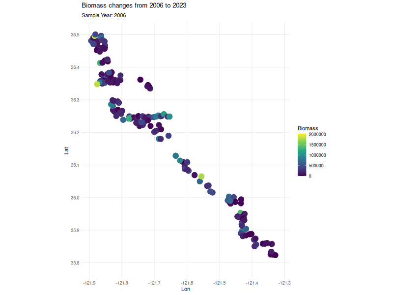

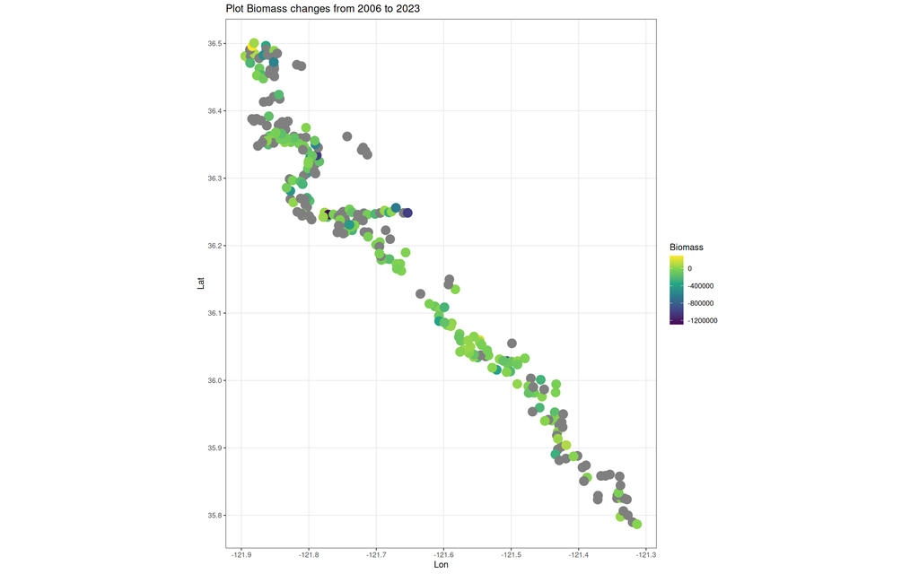

```r
min_max <- bio_ts |>
  group_by(Plot, Species) |>
  filter(SampleYear %in% c(min(SampleYear), max(SampleYear))) |>
  mutate(period = if_else(SampleYear == min(SampleYear), "min", "max")) |>
  ungroup() |>
  select(Plot, Species, period, SampleYear, LiveBiomass, TotalLiveBiomass, Lat, Lon) |>
  pivot_wider(
    names_from = period,
    values_from = c(SampleYear, LiveBiomass, TotalLiveBiomass)
  ) |>
  mutate(
    LiveBiomass_diff = LiveBiomass_max - LiveBiomass_min,
    TotalLiveBiomass_diff = TotalLiveBiomass_max - TotalLiveBiomass_min,
    LiveBiomass_pct_change = (LiveBiomass_diff / LiveBiomass_min) * 100,
    TotalLiveBiomass_pct_change = (TotalLiveBiomass_diff / TotalLiveBiomass_min) * 100
  )

map_sf2 <- min_max |> select(Plot, TotalLiveBiomass_diff, Lat, Lon)

p_map2 <- ggplot(map_sf2, aes(x = Lon, y = Lat)) +
  geom_point(aes(color = TotalLiveBiomass_diff), size=5) +
  scale_color_viridis_c(name = "Biomass", option = "D") +
  coord_sf() +
  theme_bw() +
  labs(title = "Plot Biomass changes from 2006 to 2023")

p_map2
```

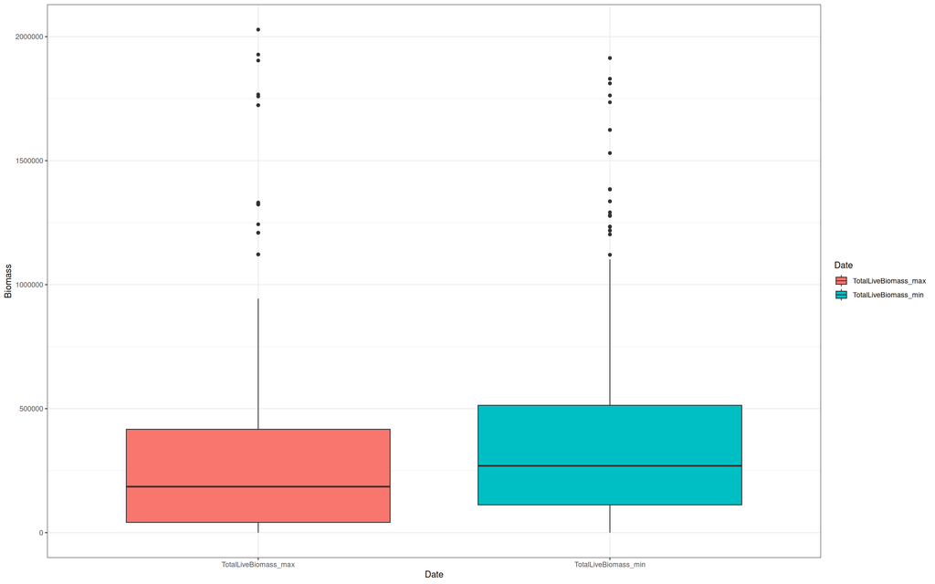

```r
diff <- min_max |>
  select(Plot, TotalLiveBiomass_min, TotalLiveBiomass_max) |>
  pivot_longer(cols = TotalLiveBiomass_min:TotalLiveBiomass_max, names_to = "Date", values_to = "Biomass")

diff |>
  ggplot(aes(x = Date, y = Biomass, fill = Date)) +
  geom_boxplot() +
  theme_bw()
```

```r
anova_diff <- aov(Biomass ~ as.factor(Date), data = diff)
summary(anova_diff)
```

```
                 Df    Sum Sq   Mean Sq F value  Pr(>F)
as.factor(Date)   1 9.918e+11 9.918e+11   6.842 0.00905 **
Residuals       920 1.334e+14 1.450e+11
---
Signif. codes:  0 '***' 0.001 '**' 0.01 '*' 0.05 '.' 0.1 ' ' 1
238 observations deleted due to missingness
```

```r
TukeyHSD(anova_diff)
```

```
  Tukey multiple comparisons of means
    95% family-wise confidence level

Fit: aov(formula = Biomass ~ as.factor(Date), data = diff)

$`as.factor(Date)`
                                             diff      lwr    upr     p adj
TotalLiveBiomass_min-TotalLiveBiomass_max 67896.5 16953.98 118839 0.0090505
```